# Post-Season ONLY

viwa

2024-08-22

### 3. Post-Season Survey Analysis

#### Where are visitors from?

*Understanding visitor hometowns by their manually collected zip codes.*

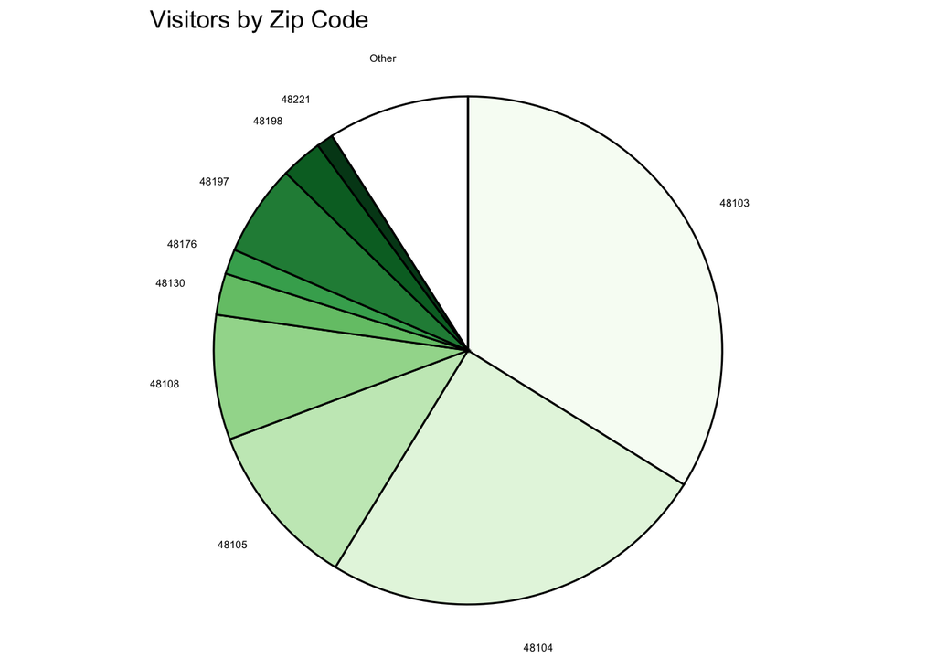

*Secondary data visualization method, mapping visitor hometowns.*

Rationale: Pie charts fail to visually assess distance and neighborhood from which participants traveled. Mapping is used to determine density and distance. First, use geocode() to add latitude and longitudes to the dataframe based on their zip code.

[interactive chart not shown]

*Visitors by home county.*

Although county data was not explicitly collected, we can extrapolate from zipcode data by using the zipcodeR package. This allows us to see zip code characteristics like population size, area in square miles, among other metadata.

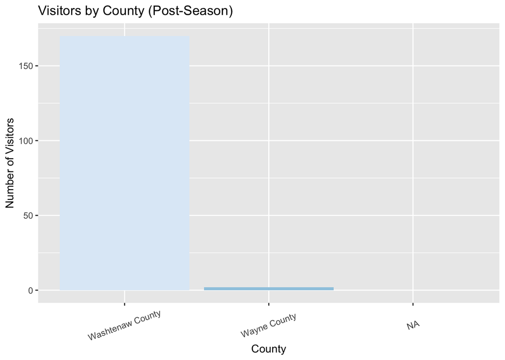

#### What ages are visitors?

*Bar graph of number of visitors by their selected age group.*

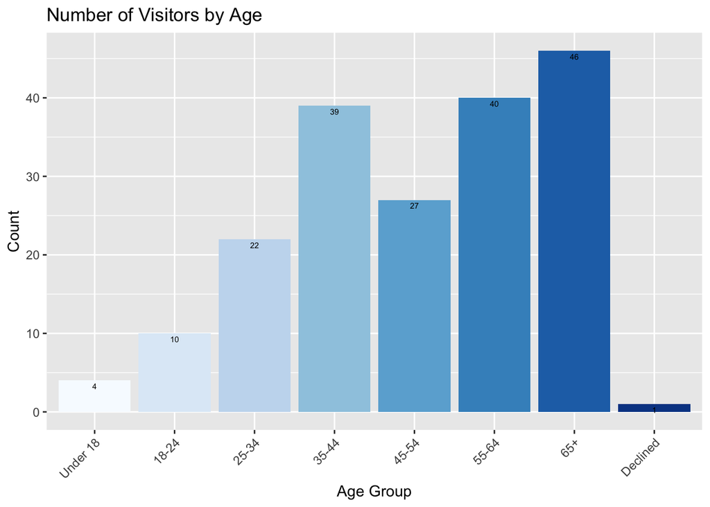

#### Visitor gender demographics

*Bar graph of number of visitors by their self-identified gender.*

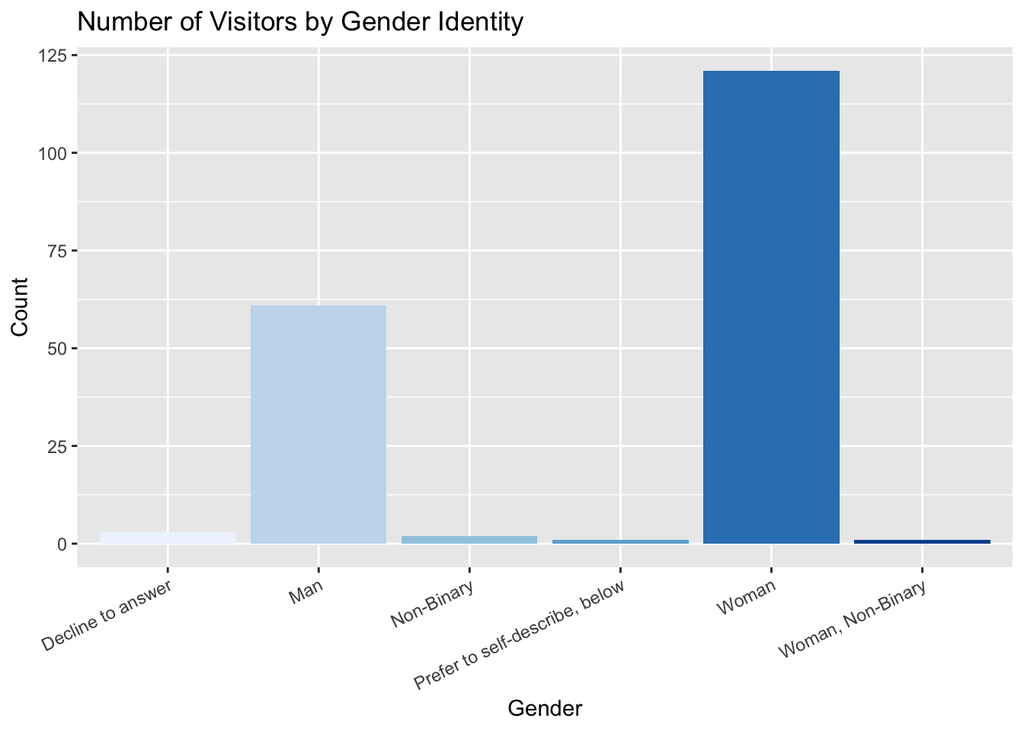

#### Ethnic demographics

*Ethnic demographics data was collected via a “Select all that apply” question, so multiple unique combinations of background were identified.*

| Race/Ethnicity | Number of Respondents |
| --- | --- |
| White | 144 |
| Asian | 15 |
| Hispanic, Latino or Spanish origin | 8 |
| Decline to answer | 6 |
| Black or African American | 4 |
| Asian, White | 2 |
| Hispanic, Latino or Spanish origin, White | 2 |
| Middle Eastern and North African (MENA) | 2 |
| American Indian or Alaska Native, White | 1 |
| Black or African American, Asian | 1 |
| Black or African American, Hispanic, Latino or Spanish origin | 1 |
| Mixed heritage | 1 |
| White, Mixed heritage | 1 |

*Create a new table that collapses multiple race and ethnicity selections into a single “Mixed heritage” category.*

Rationale: “Mixed Heritage” could be used to describe any combination of one or more racial/ethnic backgrounds, but those who also selected the combination of their backgrounds leads to many distinct demographic categorizations. A hierarchical approach that both factors a general category, as well as more common combinations, helps make the number of groups more meaningful.

| Race/Ethnicity | Count |
| --- | --- |
| White | 144 |
| Asian | 15 |
| Mixed heritage | 9 |
| Hispanic, Latino or Spanish origin | 8 |
| Decline to answer | 6 |
| Black or African American | 4 |
| Middle Eastern and North African (MENA) | 2 |

#### Visitor programming satisfaction

Programming questions were asked slightly differently between the in-season and post-season survey versions, as in-season questionnaires were administered in-time with programming.

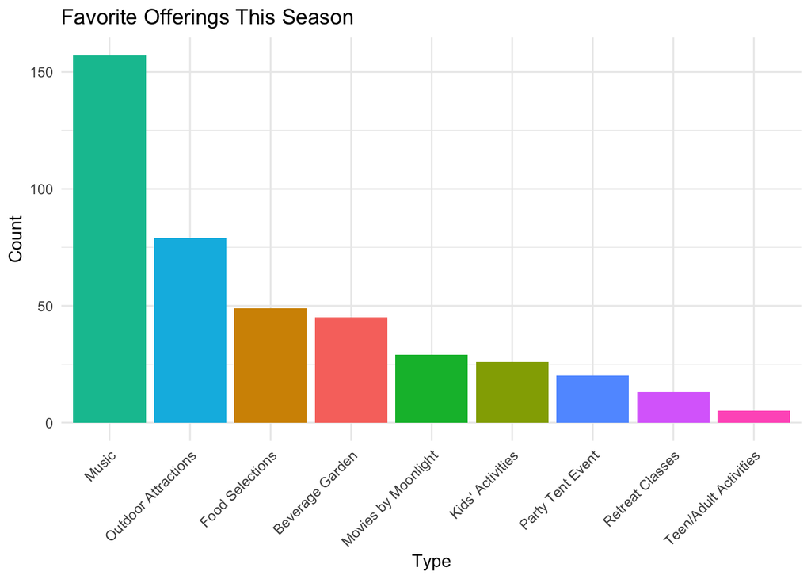

*Other respondent-identified “favorite offerings” during the in-season survey collection period.*

| Age | Other Favorite Offerings |
| --- | --- |
| 25 to 34 years | Reflex |
| 65 or older | Juggling |
| 25 to 34 years | Spoken word night |
| 35 to 44 years | Gregory Alan Isakov!!!! and Mon Rovia! |
| 35 to 44 years | loved the silent films |
| 65 or older | meet up with friends, people I have not seen for a long while; listen to god entertainment, dance outdoors |
| 65 or older | Ticketed offerings have fallen off significantly in volume and alignment with my intetrests. |
| Under 18 years | Can Chelas be allowed to sell orchatas? |

#### Family Demographics

*To filter, we choose the optional string column “On a scale of 1-10, how satisfied are you with family offerings (KidZone, Kids Rock) at Top of the Park?” to determine whether respondents represent a family.*

| Age Group | Count |
| --- | --- |
| Under 18 years | 4 |
| 18 to 24 years | 10 |
| 25 to 34 years | 22 |
| 35 to 44 years | 39 |
| 45 to 54 years | 27 |
| 55 to 64 years | 40 |
| 65 or older | 46 |
| Decline to answer | 1 |

*Most people seemed to have answered the optional “On a scale of 1-10, how satisfied are you with family offerings (KidZone, Kids Rock) at Top of the Park?”, so it may also be relevant to highlight the people who mentioned Kids’ Activities as one of their top 3 offerings.*

| Age | Top 3 Favorite Offerings | Kids’ Activities Satisfaction | Anything else to share? | Making it easier to participate | How did you hear? |
| --- | --- | --- | --- | --- | --- |
| 35 to 44 years | Music at Top of the Park, Kids’ Activities (under age 11) in KidZone | 10 | N/A | It can be hard as a parent of young kids to fully enjoy the aspects, such as the beer garden. It would be nice if it were somehow possible to more easily grab a glass of wine or a beer while also allo… | just know of it from living here |
| 35 to 44 years | Kids’ Activities (under age 11) in KidZone | 8 | all is good | Maybe if possible have some earlier starts to the events on some sat. or sun. It is hard to come so late with toddlers | have know about it for years |
| 65 or older | Music at Top of the Park, Food Selections, Kids’ Activities (under age 11) in KidZone | 8 | Some classical music would be nice. | Better weather :) | Longtime resident of Ann Arbor |
| 35 to 44 years | Music at Top of the Park, Special Outdoor Attractions (circus, street performances), Kids’ Activities (under age 11) in KidZone | 8 | None | Easier parking downtown | By seeing it downtown |
| 35 to 44 years | Music at Top of the Park, Special Outdoor Attractions (circus, street performances), Kids’ Activities (under age 11) in KidZone | 9 | Thank you for supporting so many Black artists. I’d love more Black food vendors. Please consider kid-friendly fruit and veggie options for snacks. | Nothing | N/a |
| 45 to 54 years | Music at Top of the Park, The Grove Beverage Garden, Kids’ Activities (under age 11) in KidZone | 8 | Staff was very friendly. Great experience this year as a performer. | nothing i can think of | I live in Ann Arbor |
| 65 or older | Music at Top of the Park, Special Outdoor Attractions (circus, street performances), Kids’ Activities (under age 11) in KidZone | 4 | More family friendly events. AADL has wonderful ideas! | Free parking | a2gov.org |
| 55 to 64 years | Music at Top of the Park, Special Outdoor Attractions (circus, street performances), Kids’ Activities (under age 11) in KidZone | NA | Great leadership, board, staff, and volunteers! Everyone is very friendly! | Knowing the time span of events – beginning AND approxiate end times. | I can’t remember! Friends??? |
| 35 to 44 years | Special Outdoor Attractions (circus, street performances), Food Selections, Kids’ Activities (under age 11) in KidZone | 8 | Really liked the chairs scattered around so we didn’t have to bring ours but could nab one for our family’s use. | Maybe a larger tent for kids stuff? Seemed very crowded the 2 times we went | Been on email list for a while now |
| 65 or older | Music at Top of the Park, Special Outdoor Attractions (circus, street performances), Kids’ Activities (under age 11) in KidZone | NA | It is well run | Non conflicting other obligations | Ling time attendee |
| 35 to 44 years | Special Outdoor Attractions (circus, street performances), Food Selections, Kids’ Activities (under age 11) in KidZone | 10 | Don’t charge for parking on Sundays. The city doesn’t charge, you shouldn’t either, feels yucky. | NA | Grew up going |
| 35 to 44 years | Food Selections, Kids’ Activities (under age 11) in KidZone, Teen and Adult Activities (age 11+) in the Annex | 10 | What a wonderful community offering! | None | I’ve known about it for years |
| 35 to 44 years | Music at Top of the Park, Food Selections, Kids’ Activities (under age 11) in KidZone | 10 | No | More opportunities for kid zone activities | Local, I’ve been attending for several years |
| 45 to 54 years | Special Outdoor Attractions (circus, street performances), Kids’ Activities (under age 11) in KidZone | 10 | No | Nothing | Facebook |
| 35 to 44 years | Music at Top of the Park, Movies by Moonlight, Kids’ Activities (under age 11) in KidZone | 10 | You are all great! | earlier times for the kidzone activities on the weekends would be nice, but i understand why they are later, to tie with the rest of TOP | been around ;) |
| 35 to 44 years | Music at Top of the Park, The Grove Beverage Garden, Kids’ Activities (under age 11) in KidZone | 8 | Look forward to it every year! | Big bike parking area, perks for riding/walking instead of driving | Friends |
| 35 to 44 years | Music at Top of the Park, Special Outdoor Attractions (circus, street performances), Kids’ Activities (under age 11) in KidZone | 8 | Thank you! | N/A | Friends |
| 45 to 54 years | Music at Top of the Park, Kids’ Activities (under age 11) in KidZone | 10 | Great vibe, very organized, love the variety of programming. Could there be more or different food options? | Nothing! | Been coming for over 20 years |
| 35 to 44 years | Special Outdoor Attractions (circus, street performances), Food Selections, Kids’ Activities (under age 11) in KidZone | 9 | Please go back to when TOP was all of June! Every year it gets shorter and shorter making less and less days my family can attend. The free entertainment and vibe at TOP should be top priority - not t… | Open all of June and free! | No idea it’s been so long ago now. |
| Decline to answer | Kids’ Activities (under age 11) in KidZone, Teen and Adult Activities (age 11+) in the Annex, I was invited to an event in the party tent | 10 | Nice to have some chairs out on the lawn area this year. Seems like folks enjoyed those. Good to have some interesting and different performing art opportunities, like the silent films and street perf… | Not much, did not like the program this year, schedule was not by calendar date, it was by type of event, and very hard to keep track of what was going on and what you wanted to attend. | I donate every year, and living in the Downtown Ann Arbor Area it is hard to miss. |
| 45 to 54 years | Music at Top of the Park, Food Selections, Kids’ Activities (under age 11) in KidZone | 9 | Thank you all for continuing all the work required for these wonderful events | Increased parking options | Mainly email notifications, but the paper schedule is also much appreciated |
| 35 to 44 years | Kids’ Activities (under age 11) in KidZone | 10 | More restaurant options or food trucks would be great | Timing- earlier better for kids | Online |
| 25 to 34 years | Music at Top of the Park, Food Selections, Kids’ Activities (under age 11) in KidZone | 8 | We always wish top of the park were longer. We would have loved to come even more than we did. | Add more days :) | Have been coming to ToP forever |
| 35 to 44 years | Music at Top of the Park, Special Outdoor Attractions (circus, street performances), Kids’ Activities (under age 11) in KidZone | 10 | Was quite busy and hard to find seats. Not sure if there is possibly a bigger location with better parking? Kids options were also 10/10 awesome! | Parking | Family member |
| 35 to 44 years | Music at Top of the Park, Special Outdoor Attractions (circus, street performances), Kids’ Activities (under age 11) in KidZone | 10 | Nothing | Nothing | Social Media |
| 35 to 44 years | Music at Top of the Park, Special Outdoor Attractions (circus, street performances), Kids’ Activities (under age 11) in KidZone | 8 | None | None | Friends! |